# Encontrar candidatos a novos registros estaduais e de domínios

Aqui apresentamos um guia prático para a função `flora_distribution_gap()` do pacote `floraR`. Dado um gênero ou espécie de plantas ou algas, ela compara os estados brasileiros onde espécimes do táxon foram registrados com os estados listados oficialmente na sua distribuição na [Flora e Funga do Brasil (FFB)](https://floradobrasil.jbrj.gov.br/consulta/), e sinaliza os estados que ainda não constam da FFB como **candidatos a novos registros estaduais** - por exemplo, uma espécie listada pela FFB apenas para a Bahia, mas com espécimes de herbário de Pernambuco.

Os registros georreferenciados também são situados nos seis **domínios fitogeográficos** brasileiros, para sinalizar da mesma forma candidatos a novos registros de domínio.

Manter as distribuições completas faz parte de expandir as monografias da FFB: cada candidato é uma pista a ser verificada pelo especialista do grupo.

## Como a comparação funciona

1. **Lado da FFB.** Os estados listados oficialmente vêm do conjunto de dados da FFB armazenado localmente (baixado apenas quando necessário, como em `flora_download()`). Para um **gênero**, os estados de todas as suas espécies e táxons infraespecíficos são combinados; para uma **espécie**, os da espécie e dos seus táxons infraespecíficos. Se o nome for um **sinônimo** na FFB, é usada a distribuição do seu nome aceito.
2. **Evidência de ocorrência.** Os registros brasileiros do táxon são contados por estado, a partir de uma ou mais fontes (veja abaixo).
3. **Comparação.** Todo estado com registros que a FFB não lista é sinalizado como candidato a novo registro estadual.

As bases de dados de ocorrência registram os estados como texto livre, com muitas grafias - só o GBIF usa `"Goiás"`, `"Go"`, `"Est. do Bahia"`, `"Paraiba"` ou `"Brasília"` para o Distrito Federal. Todas são normalizadas para os nomes de estados da FFB antes da comparação, e valores que não são estados brasileiros são ignorados.

## De onde vem a evidência

[output not shown]

## Encontrar candidatos a novos registros estaduais para uma espécie

```r
library(floraR)

gap <- flora_distribution_gap(taxon = "Luetzelburgia auriculata")
```

A função retorna uma lista de três tabelas - `gap$states`, `gap$domains` e `gap$records` - e também as salva como abas de uma planilha `.xlsx`, junto com um relatório HTML autocontido, na pasta `flora_distribution_gap/`. `gap$states` tem uma linha por estado brasileiro com qualquer evidência:

| Coluna | Significado |
| --- | --- |
| `State` | Estado brasileiro. |
| `In_FFB_distribution` | Se a FFB já lista o estado para o táxon. |
| `GBIF_records`, `Reflora_records`, `speciesLink_records` | Número de registros no estado, para cada fonte consultada. |
| `New_state_record_candidate` | `TRUE` para estados com registros que a FFB não lista. |

Para *Luetzelburgia auriculata*, a FFB lista 14 estados, e os registros do GBIF apontam para mais cinco - Alagoas, Paraná, Rio de Janeiro, Rio Grande do Sul e São Paulo.

## Verificar os registros por trás de cada candidato

Registros de ocorrência são evidências a revisar, não provas: um registro de um novo estado pode ser uma planta cultivada, uma identificação equivocada ou um erro de georreferenciamento. Por isso, o relatório HTML lista os registros individuais encontrados em cada estado candidato - coletor e número, data, localidade, herbário e número de catálogo, e o nome sob o qual o espécime foi identificado - cada um com link para o próprio registro, para que cada candidato possa ser verificado antes de entrar na FFB.

## Domínios fitogeográficos

Além dos estados, os registros do GBIF que têm coordenadas são situados nos seis domínios fitogeográficos brasileiros - Amazônia, Caatinga, Cerrado, Mata Atlântica, Pampa e Pantanal - usando o mapa de biomas do IBGE (2019) incluído no `floraR`. Um domínio com registros, mas não listado para o táxon na FFB, é um **candidato a novo registro de domínio**. Registros que o GBIF marca com problemas geoespaciais (como coordenadas zeradas, ou fora do país indicado) são deixados de fora.

```r
gap$domains                                          # uma linha por domínio
gap$records[gap$records$New_domain_record_candidate, ]  # os registros por trás dos novos domínios
```

| Domínio | Na FFB | Registros georreferenciados | Candidato a novo domínio |
| --- | --- | --- | --- |
| Amazônia | sim | 10 |  |
| Caatinga | sim | 539 |  |
| Cerrado | sim | 183 |  |
| Mata Atlântica | não | 7 | **sim** |

O relatório HTML mapeia todos os registros georreferenciados sobre os domínios, coloridos por situação - clique em um ponto para ver o coletor, a data, o herbário e um link para o registro:

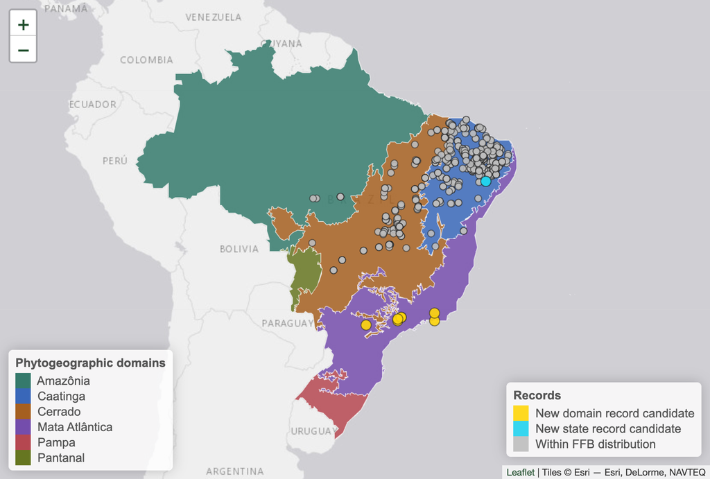

Os registros georreferenciados de *Luetzelburgia auriculata* no GBIF sobre os domínios fitogeográficos brasileiros, nas cores dos domínios da FFB: em amarelo, os candidatos a novo registro de domínio na Mata Atlântica; em ciano, um candidato a novo registro estadual.

Um registro próximo ao limite entre domínios, ou um único registro em um novo domínio, merece uma verificação mais cuidadosa - pode ser uma planta cultivada ou um erro de georreferenciamento. A análise de domínios requer o pacote `sf`, e o mapa, o pacote `leaflet`; use `domains = FALSE` para omiti-la.

## Um gênero inteiro, ou estados selecionados

Para um gênero, a distribuição na FFB é a união das distribuições de todas as suas espécies:

```r
gap_genus <- flora_distribution_gap(taxon = "Luetzelburgia")
```

Para verificar apenas alguns estados (nomes completos ou siglas, com ou sem acentos):

```r
gap_ne <- flora_distribution_gap(taxon = "Luetzelburgia auriculata",
                                 state = c("PE", "Paraiba", "Alagoas"))
```

## Adicionar mais fontes

```r
# Espécimes dos herbários do REFLORA (requer o refloraR)
gap_reflora <- flora_distribution_gap(taxon = "Luetzelburgia auriculata",
                                      sources = c("gbif", "reflora"))

# speciesLink, com a sua chave de API na variável de ambiente SPECIESLINK_KEY
gap_splink <- flora_distribution_gap(taxon = "Luetzelburgia auriculata",
                                     sources = c("gbif", "speciesLink"))
```

## Argumentos

| Argumento | Descrição |
| --- | --- |
| `taxon` | Um único nome de gênero ou espécie de plantas ou algas. |
| `state` | Estados brasileiros opcionais aos quais restringir a verificação. `NULL` (padrão) verifica todos. |
| `sources` | Qualquer combinação de `"gbif"` (padrão), `"reflora"` e `"speciesLink"`. |
| `specieslink_key` | Chave de API do speciesLink. Padrão: a variável de ambiente `SPECIESLINK_KEY`. |
| `domains` | Se `TRUE` (padrão), também situa os registros georreferenciados nos domínios fitogeográficos. Requer o pacote `sf`. |
| `max_coordinates` | Número máximo de registros georreferenciados do GBIF lidos para a análise de domínios. Padrão `5000`. |
| `version` | Versão do conjunto de dados da FFB usada na comparação. Padrão `"latest"`. |
| `save`, `dir`, `filename` | Salva o resultado como planilha `.xlsx`, e onde. |
| `html_report`, `open_report` | Gera o relatório HTML e o abre no navegador. |
| `verbose` | Exibe mensagens de progresso. Padrão `TRUE`. |

## Dicas Adicionais

- Um único registro em um novo estado merece mais atenção do que dezenas: verifique o espécime, a sua identificação e se ele era cultivado.
- Alguns táxons não têm nenhuma distribuição por estado na FFB (como algumas algas marinhas); a função então informa isso, e todos os estados com registros são sinalizados.
- O relatório HTML requer os pacotes `rmarkdown`, `DT` e `htmltools`. Sem eles, o relatório é omitido com uma mensagem, e a planilha continua sendo salva.

## Veja Também

- Encontrar espécies ausentes da FFB
- Filtrar e recuperar registros da lista de espécies